# Tree diversity effects on litter decomposition are mediated by litterfall and microbial processes - Beugnon - Oikos - Wiley Online Library

[Oikos](https://onlinelibrary.wiley.com/journal/16000706)

[Early View](https://onlinelibrary.wiley.com/toc/16000706/0/0) e09751

[figure not shown]

Research article

Open Access

# Tree diversity effects on litter decomposition are mediated by litterfall and microbial processes

[Rémy Beugnon](https://onlinelibrary.wiley.com/authored-by/Beugnon/R%C3%A9my),

[Nico Eisenhauer](https://onlinelibrary.wiley.com/authored-by/Eisenhauer/Nico),

[Helge Bruelheide](https://onlinelibrary.wiley.com/authored-by/Bruelheide/Helge),

[Andréa Davrinche](https://onlinelibrary.wiley.com/authored-by/Davrinche/Andr%C3%A9a),

[Jianqing Du](https://onlinelibrary.wiley.com/authored-by/Du/Jianqing),

[Sylvia Haider](https://onlinelibrary.wiley.com/authored-by/Haider/Sylvia),

[Georg Hähn](https://onlinelibrary.wiley.com/authored-by/H%C3%A4hn/Georg),

[Mariem Saadani](https://onlinelibrary.wiley.com/authored-by/Saadani/Mariem),

[Bala Singavarapu](https://onlinelibrary.wiley.com/authored-by/Singavarapu/Bala),

[Marie Sünnemann](https://onlinelibrary.wiley.com/authored-by/S%C3%BCnnemann/Marie),

[Lise Thouvenot](https://onlinelibrary.wiley.com/authored-by/Thouvenot/Lise),

[Yanfen Wang](https://onlinelibrary.wiley.com/authored-by/Wang/Yanfen),

[Tesfaye Wubet](https://onlinelibrary.wiley.com/authored-by/Wubet/Tesfaye),

[Kai Xue](https://onlinelibrary.wiley.com/authored-by/Xue/Kai),

[Simone Cesarz](https://onlinelibrary.wiley.com/authored-by/Cesarz/Simone),

First published: 12 July 2023

https://doi.org/10.1111/oik.09751

## Abstract

Forest ecosystems are critical for their carbon sequestration potential. Increasing tree diversity has been shown to enhance both forest productivity and litter decomposition. Litter diversity increases litter decomposability by increasing the diversity of substrates offered to decomposers. However, the relative importance of litter decomposability and decomposer community in mediating tree diversity effects on decomposition remains unknown. Moreover, tree diversity modulation of litterfall spatial distribution, and consequently litter decomposition, has rarely been tested. We studied tree diversity effects on leaf litter decomposition and its mediation by the amount of litterfall, litter species richness and decomposability, and soil microorganisms in a large-scale tree diversity experiment in subtropical China. Furthermore, we examined how litter functional identity and diversity affect leaf litter decomposability. Finally, we tested how leaf functional traits, tree biomass, and forest spatial structure drive the litterfall spatial distribution. We found evidence that tree species richness increased litter decomposition by increasing litter species richness and the amount of litterfall. We showed that soil microorganisms in this subtropical forest perform 84–87% of litter decomposition. Moreover, changes in the amount of litterfall and microbial decomposition explained 19–37% of the decomposition variance. Additionally, up to 20% of the microbial decomposition variance was explained by litter decomposability, while litter decomposability itself was determined by litter functional identity, diversity, and species richness. Tree species richness increased litter species richness and the amount of litterfall (+200% from monoculture to eight-species neighborhood). We further demonstrated that the amount of species-specific litterfall increased with increasing tree proximity and biomass, and was modulated by leaf functional traits. These litterfall drivers increased the spatial heterogeneity of litter distribution, and thus litter decomposition. We highlighted multiple biomass- and diversity-mediated effects of tree diversity on ecosystem properties driving forest nutrient cycling. We conclude that considering spatial variability in biotic properties will improve our mechanistic understanding of ecosystem functioning.

## Introduction

Forest ecosystems have been highlighted for their carbon sequestration potential in both above- and belowground compartments (Lewis et al. 2019), especially in species-rich forests (Liang et al. 2016, Liu et al. 2018, Xu et al. 2020). Recycling of dead tree organic matter (e.g. leaf litter or dead wood) controls the release of carbon (C) and other nutrients from the aboveground compartment into the soil (Seibold et al. 2021). These processes become even more important in highly productive ecosystems, such as subtropical Chinese forests (Yu et al. 2014), where high amounts of dead organic matter are released (Liu et al. 2018), and where it is therefore critical to understand the drivers of decomposition processes to maintain longterm productivity sustainably.

Decomposition – including the fragmentation of litter, its incorporation into the soil, and its mineralization due to enzymatic activities – is the main recycling process of leaf litter in forests (Coûteaux et al. 1995, Hättenschwiler 2005). Tree species richness has been shown to increase decomposition (Gartner and Cardon 2004, Gessner et al. 2010, Trogisch et al. 2016, Joly et al. 2017), thus enhancing the incorporation of organic matter into the soil compartment (Gartner and Cardon 2004, Lange et al. 2015). Litter decomposition is further carried out by meso- and macro-decomposers (García-Palacios et al. 2013) interacting with microbial communities (Joly et al. 2018). However, the relative importance of microbial communities in carrying out decomposition remains unclear. Tree species richness, and as a consequence litter species richness, is expected to increase decomposer biomass and diversity by providing a higher diversity of substrates and increasing niche partitioning of the decomposer community (Ebeling et al. 2014, Hooper et al. 2000). In addition, litter species richness should increase litter decomposability (Lin and Zeng 2018, Zhou et al. 2020); that is, the ability of litter to decompose when measured in a controlled environment (Freschet et al. 2012). Litter decomposability should, in turn, promote litter decomposition by providing an easily degradable litter to the decomposer community, especially by promoting the microbial community functions (Bonner et al. 2018, Rosenfield et al. 2020). However, the relative contributions of litter decomposability and the soil decomposer community in mediating tree diversity effects on litter decomposition remain untested.

Litter decomposability quantifies how decomposition responds to changing substrate composition, i.e. the effect of litter on decomposition when controlling for the effects on decomposer community or environmental conditions. Litter decomposability is strongly driven by leaf functional trait identity and diversity (Freschet et al. 2012, Seidelmann et al. 2016, Rosenfield et al. 2020, Zhou et al. 2020). For example, litter quality-related leaf functional traits (i.e. lower C:N and C:P ratios) enhance litter decomposition by increasing the availability of limiting nutrients (Fanin et al. 2012, Zhang et al. 2018, Patoine et al. 2020). Moreover, higher litter species richness promotes litter decomposability by increasing litter chemical dissimilarity and favoring nutrient transfer from nutrient-rich leaves to nutrient-poor leaves (Schimel and Hättenschwiler 2007). However, the relative contributions of leaf litter functional trait identity and diversity on decomposability remain rarely tested, especially in a large pool of species and species mixtures (Lin et al. 2021).

Changes in tree diversity affect the amount of litterfall and litter species richness at the plot level (Huang et al. 2017). For example, tree species richness has been shown to increase forest productivity (Huang et al. 2018), including litterfall biomass (Huang et al. 2017). In species-rich forests, the spatial arrangement of tree species in the plot (i.e. tree planting pattern) could also be expected to influence the spatial distribution of litter and, thus, litter composition (i.e. amount of species-specific litter) and decomposition. Moreover, we could expect litter distribution across space to be affected by species identity according to their leaf functional traits. For example, as leaf size increases, leaves should be transported further away from the source tree (Chandler et al. 2008). However, little is known about the effects of leaf functional traits and tree productivity on spatial patterns of litterfall distribution and the consequences for decomposition processes.

In this study we aim to mechanistically understand tree species richness effects on leaf litter decomposition by considering the amount of litterfall and litter composition; the factors that affect litter composition (e.g. tree biomass, leaf functional traits, and tree spatial organization); litter decomposability; and the mediation by microbial processes. We hypothesized that tree species richness increases litter decomposition (H1, Fig. 1), and that litter decomposition is driven by the soil microbial community (H2). Furthermore, we expected that increasing the amount of litterfall and litter decomposability increases microbial decomposition (H3), and that litter diversity and nutrient availability (e.g. litter N and P concentrations) increase litter decomposability (H4). Finally, we hypothesized the spatial distribution of litterfall to be driven by tree biomass, leaf functional traits, and the spatial distribution of the trees in the plot (H5).

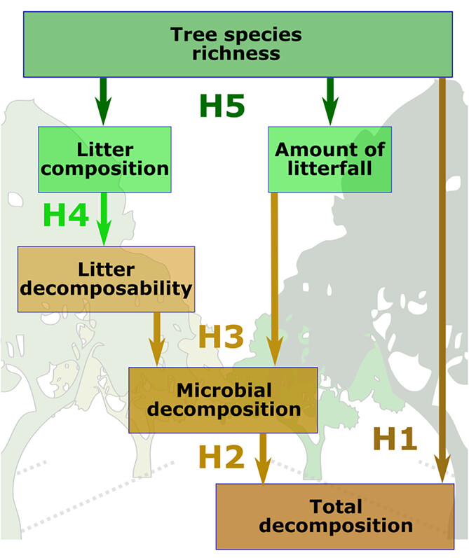

**Figure 1**

Conceptual framework of the study. Relationships between the different hypotheses tested in this study: H1 – tree species richness increases total litter decomposition; H2 – total litter decomposition is carried out mainly by the soil microbial community; H3 – microbial decomposition increases with the amount of litterfall and litter decomposability (i.e. litter decomposition measured in a controlled environment); H4 – litter diversity and nutrient availability (e.g. litter N, P concentrations) increase litter decomposability; H5 – the litterfall composition (i.e. amount of species-specific litter) is driven by tree biomass, leaf functional traits, and the spatial distribution of the trees in the plot.

## Material and methods

### Study design

To identify the effect of tree spatial organization on litterfall distribution and decomposition, we measured litterfall and decomposition between tree species pairs (hereafter, TSP) across various neighborhoods. Each TSP consisted of two trees next to each other (~1.28 m), and we defined its neighborhood as the ten trees directly adjacent in the planting grid. Each TSP was replicated three times in five tree species richness levels (1, 2, 4, 8, and ≥ 16 species), when available according to the experimental design (see ‘broken stick design', Bruelheide et al. 2014). In total, we surveyed 24 combinations of tree species resulting in a total of 180 TSPs in 52 plots (Supporting information).

### Litterfall sampling

In September 2018, a litter trap of 1 m<sup>2</sup> was set up at a height of 1 m above the soil surface between each TSP (Supporting information). Litter was collected in December 2018 to cover the main litterfall season in the region (Huang et al. 2017). To measure litterfall composition (i.e. species-specific litter biomass), each leaf of the litter trap was sorted and identified to species level. Each species' litter was dried at 40°C for two days and weighed (± 0.1 g). Litter species richness was assessed as the number of species identified in the trap, and the total amount of litterfall was calculated as the sum of the dried biomass of all species in 1 m<sup>2</sup>.

### Litter decomposition experiments

We performed two complementary decomposition experiments: one in the TSPs to measure microbial and total decomposition (H1–2), and one in a common garden experimental field site to assess decomposability (H3–4; Supporting information).

For both experiments, litterbags (10 × 10 cm), with different mesh sizes (details below) were filled with 2 g (± 0.01 g) of dried litter according to litter trap species composition (i.e. amount of species-specific litter) of the different TSPs. Therefore, the litter composition of the litterbags matched the litterfall composition collected in the corresponding TSP. The litterbags for both experiments were installed in December 2018 and collected in September 2019 before litterfall, i.e. after nine months of decomposition when about 30–50% of mass loss is expected in this area (Lin et al. 2021) while avoiding interaction with freshly fallen litter. The litterbags were water-cleaned by dissolution and gentle removal of soil particles as well as being dried at 40°C for two days. The residual litter was weighed (± 0.01 g) and milled for further chemical content analyses. The effect of water-cleaning treatment of the bag on litter loss was considered neglectable in comparison to heavy rain and sediment runoff in the region (e.g. up to 250 mm of precipitation on average in May between 2009 and 2012, with up to 130 mm in 24 h in 2010 and significant runoff, Seitz et al. 2015).

#### Decomposition experiment in between the TSPs

To assess total litter decomposition (total C and N loss, including fauna-mediated decomposition) and microbial decomposition (microbial C and N loss, excluding fauna-mediated decomposition), two large-mesh (5-mm mesh, total litter decomposition) and two small-mesh (0.054-mm mesh, microbial decomposition) litterbags were set up between the TSPs, respectively, with plot-specific litter. Small-mesh litter bags excluded meso- and macro-detritivores by using a fine mesh size (0.054-mm mesh) to assess microbial decomposition, while large-mesh litter bags were built using a 5-mm mesh in the upper half of the bag to provide access to macro-decomposers, and a 0.054-mm mesh only at the bottom to prevent loss of fine leaf litter particles to assess total litter decomposition (Bradford et al. 2002). All litterbags were covered by a 50 × 50 cm grid to prevent heavy rainfalls from dislocating the litterbags (1 cm mesh size, Supporting information).

#### Decomposition experiment in the common garden

The common garden decomposition experiment was performed in a monoculture from the BEF China site to ensure decomposition experiments were performed under comparable environmental conditions (e.g. seasonal macroclimatic fluctuations). The setting consisted of a monoculture stand of *Schima superba*, a species that was not included in the TSP experiment; thereby, we were able to exclude any home-field advantages (Fanin et al. 2021). *Schima superba* was chosen to maximize the phylogenetic distance with our target species and minimize environmental heterogeneity within the plot (i.e. productive species with closed canopy). The litter from *S. superba* was removed from the ground before deploying the litterbags at a distance of 10 cm from each other in two blocks (one TSP replicate per block, Supporting information). To measure litter decomposability, two small-mesh litterbags (0.054-mm mesh) representing the litter composition of each TSP were incubated in the common garden experiment. Only small-mesh litterbags were considered to avoid interaction between litterbags from different TSP (e.g. composition over-attracting the macro-decomposers).

### Leaf and litter trait measurements

Leaf functional traits were assessed at the species- and plot-level in September 2018, following Davrinche and Haider (2021). For each TSP species, several fresh leaves were collected, and the reflectance spectra were measured using an ASD FieldSpec® 4 wide-resolution spectroradiometer. Leaf functional traits were predicted from the reflectance spectra of a calibration dataset of the same species, where both reflectance spectra and leaf functional traits were measured. For leaf morphological traits – specific leaf area (SLA, leaf area divided by dry weight) and leaf dry matter content (LDMC, ratio of leaf dry weight to fresh weight) were measured before and after drying for 72 h at 80°C. Leaf areas were measured from scans with a resolution of 300 dpi of the fresh leaves using the WinFOLIA software. Leaf chemical contents, i.e. carbon (C), nitrogen (N), phosphorus (P), magnesium (Mg), calcium (Ca), and potassium (K) contents, were measured from dried leaves ground into a fine powder. About 5 mg of leaf powder was used to determine C and N contents with an elemental analyzer; a 200 mg-subsample was used to measure P content via nitric acid digestion and spectrophotometry using the acid molybdate technique. The filtrate resulting from nitric acid digestion was analyzed with atomic absorption spectrometry for Mg, Ca, and K contents. Of these calibration samples, the relation between the leaf spectra and the measured leaf traits was analyzed with the software Unscrambler X (ver. 10.1) to predict leaf functional traits of each leaf, then averaged at species- and plot-specific. For each litterbag, we calculated the total amount of nutrients (i.e. C, N, P, Mg, Ca, K) as the sum of all species' contributions, and leaf morphological traits community weighted mean (i.e. CWM SLA and LDMC) using species-specific litter dry weight and species- and plot-specific leaf functional traits. In addition, we calculated the variance of each litter functional trait (i.e. C, N, P, Mg, Ca, K, SLA, LDMC) within the litterbags.

Litter C and N content after decomposition was measured from the residual litter with an elemental analyzer. To estimate soil contamination, the ash content of the sample was measured as it represents the amount of soil using the loss on ignition method. Soil contamination was thus estimated as:

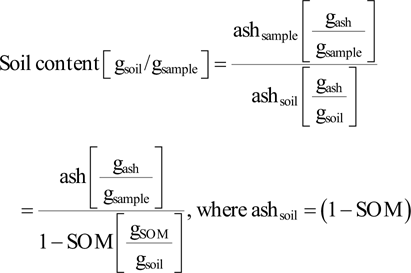

(see Supporting information for details).

### Decomposition measures

C and N loss (%) in the litterbags between December 2018 and September 2019 were used as a measure of the total decomposition (i.e. measured via the large mesh-size in the TSP experiment), microbial decomposition (i.e. using small mesh size in the TSP experiment), and litter decomposability (i.e. using small mesh size in the common garden experiment).

### Statistical methods

See Supporting information for a description of all the variables used in this study. All data handling and statistical calculations were performed using the R statistical software ver. 4.1.0 ([www.r-project.org](http://www.r-project.org/)). All of the following linear multiple-predictors models were tested in R using the *lm* function ([www.r-project.org](http://www.r-project.org/)), and statistical hypotheses (i.e. residuals normality, homoscedasticity, homogeneity of variance) of the following linear models were tested using the *model_check* function from the ‘performance' package (Lüdecke et al. 2020, Supporting information).

#### Tree diversity effect on C and N loss (H1)

We used linear models and normal distribution assumptions to test the effects of neighborhood tree species richness on total decomposition (‘C loss' and ‘N loss' measured between the TSPs) and microbial decomposition (‘C loss' and ‘N loss' measured between the TSPs, when soil meso- and macro-fauna were excluded). In addition, we used linear models and normal distribution assumptions to test the effects of litter species richness on litter decomposability (‘C loss' and ‘N loss' measured in the common garden experiment).

#### Tree diversity effect on the amount of litterfall and litter species richness

We used linear models and normal distribution assumptions to test the effect of neighborhood tree species richness on the amount of litterfall, and litter species richness.

#### Mediation of tree species richness effects on litter decomposition

To test the effects of litter species richness on litter decomposability (‘C loss' and ‘N loss' in the common garden experiment), we used linear models and normal distribution assumptions. To test the effects of litter species richness, amount of litterfall, and decomposability (‘C loss' and ‘N loss' in the common garden experiment) on litter microbial decomposition (‘C loss' and ‘N loss' between the TSPs, when soil meso- and macro-fauna were excluded), we used linear multiple predictor models and normal distribution assumptions, where all predictor values were rescaled using the R function *scale* ([www.r-project.org](http://www.r-project.org/)). To test the effects of litter species richness, amount of litterfall, and litter microbial decomposition (‘C loss' and ‘N loss' between the TSP, when soil meso- and macro-fauna were excluded) on litter decomposition (‘C loss' and ‘N loss' between the TSP, when soil meso- and macro-fauna were included), we used linear multiple predictor models and normal distribution assumptions, where all predictor values were rescales using the R function *scale* ([www.r-project.org](http://www.r-project.org/) – H2). See Supporting information for all previously cited model outputs.

To test the mediation of tree species richness effects on litter decomposition by the amount of litterfall and litter species richness effects on decomposability, we implemented the previous relationships in a structural equation model (SEM) framework (see Supporting information for model structure); this comparison being possible as 1) each TSP litter composition was replicated in all experiments, 2) all three on-site experiments were temporally synchronous, and 3) all variables were centered and reduced to compare effect sizes. Our SEM was fitted using the *sem* function from the ‘lavaan' package (Rosseel 2012). The quality of our model fit on the data was estimated using three complementary indices: 1) the root-mean-squared error of approximation (RMSEA), 2) the comparative fit index (CFI), and 3) the standardized root mean squared residuals (SRMR); a model fit was considered acceptable when RMSEA < 0.10, CFI > 0.9 and SRMR < 0.08.

## Results

### Tree species richness increases nitrogen loss

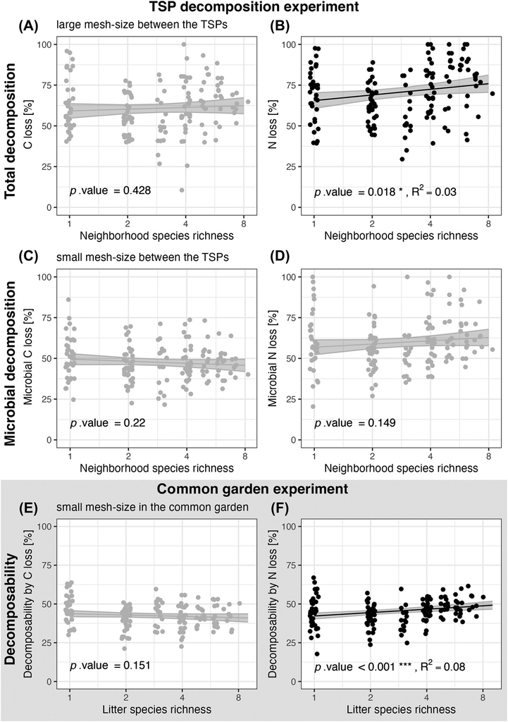

**Figure 2**

Neighborhood tree species richness effect on total litter decomposition using large mesh-size litterbags (5 mm mesh, A and B), microbial decomposition using small mesh-size litterbags (0.054 mm mesh, C and D), and tree litter species richness effect on litter decomposability measured under controlled conditions in the common garden experiment using small-mesh size litterbags (0.054 mm mesh, E and F). The values represent carbon and nitrogen loss (in %) after nine months of leaf litter decomposition in a subtropical Chinese forest. For better readability, the values were jittered, and non-significant relationships (i.e. p-value > 0.05) were grayed.

### Tree species richness affects litterfall, with consequences for litter decomposition

Our model revealed a positive effect of neighborhood tree species richness on the amount of litterfall and litter species richness (estimate ± SE = 52.3 ± 8.24, p-value < 0.001; 1.00 ± 0.05, p-value < 0.001, respectively; Fig. 3A). In the common garden experiment, where litter decomposability was investigated, litter species richness of the litterbags increased litter N loss (0.29 ± 0.07, p-value < 0.001, Fig. 3C), and explained up to 8% of its variance but did not affect litter C loss. Litter decomposability, in turn, increased microbial decomposition (Fig. 3C), by increasing microbial C loss (0.43 ± 0.05, p-value < 0.001), explaining 19% of the variance in microbial C loss (Fig. 3C). Similarly, microbial N loss increased with increasing litter decomposability (0.36 ± 0.06, p-value < 0.001), explaining up to 19% of the variance in microbial N loss. Microbial decomposition represented the major part of litter decomposition: 84% (±40%) of C loss and 87% (±22%) of N loss were carried out by the microbial community (Fig. 3B). Litter C loss by microbial decomposition and the amount of litterfall explained up to 19% of litter C loss, both increasing total litter C loss (0.27 ± 0.05, p-value < 0.001, and 0.33 ± 0.09, p-value < 0.001, respectively, Fig. 3C). Similarly, microbially-mediated N loss and the amount of litterfall increased total litter N loss (0.49 ± 0.05, p-value < 0.001, and 0.24 ± 0.08, p-value = 0.003), explaining 37% of the variance in litter N loss.

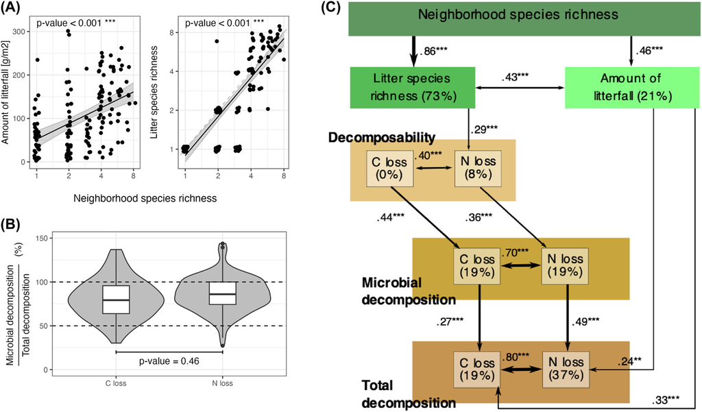

**Figure 3**

Tree species effect on the amount of litterfall and litter species richness, as well as consequences for litter decomposition. (A) Neighborhood species richness effect on the amount of litterfall and litter species richness (values were jittered for better readability). (B) Percentage of total decomposition carried out by the microbial community. (C) Structural equation model (SEM) linking neighborhood species richness, litterfall, and decomposition processes (i.e. decomposability in terms of litter ‘C loss' and ‘N loss' in a common garden experiment, microbial decomposition in terms of litter ‘C loss' and ‘N loss', and total decomposition in terms of ‘C loss' and ‘N loss'). Only significant paths (p-value < 0.05) are reported with an arrow in the figure (see Supporting information for the whole model structure). Arrow widths were scaled by the standardized effect size of significant relations. Correlations between nodes were drawn with double-headed arrows, while causal relations were drawn with one-way arrows. The variance explained by the model (R<sup>2</sup>, in %) is shown after each node name. The significance levels were standardized across the panels (‘.': p-value < 0.1, ‘*': p-value < 0.05, ‘**': p-value < 0.01, and ‘***': p-value < 0.001).

### Drivers of litterfall composition

Our analyses of litterfall composition (i.e. amount of species-specific litterfall) highlighted the effect of tree biomass, tree ecological strategies, and the spatial arrangement of the trees at the locations of litter collection (Fig. 4D). These three aspects together explained up to 47% of the variance in amount of species-specific litterfall. The amount of species-specific litterfall increased with tree biomass (estimate ± SE = 0.58 ± 0.04, p-value < 0.001) and the proximity to the trees (0.10 ± 0.04, p-value = 0.017), and was modulated by changes in tree ecological strategies (i.e. LES 1: estimate ± SE = −0.08 ± 0.04, p-value = 0.03; LES 2: −0.14 ± 0.04, p-value < 0.001). Specifically, the first leaf economics spectrum axis (i.e. ‘LES 1') was positively correlated with the leaf LDMC and negatively with the leaf SLA (Pearson correlation: LES 1-LDMC = 82 %, LES 1-SLA = −91%, Supporting information).

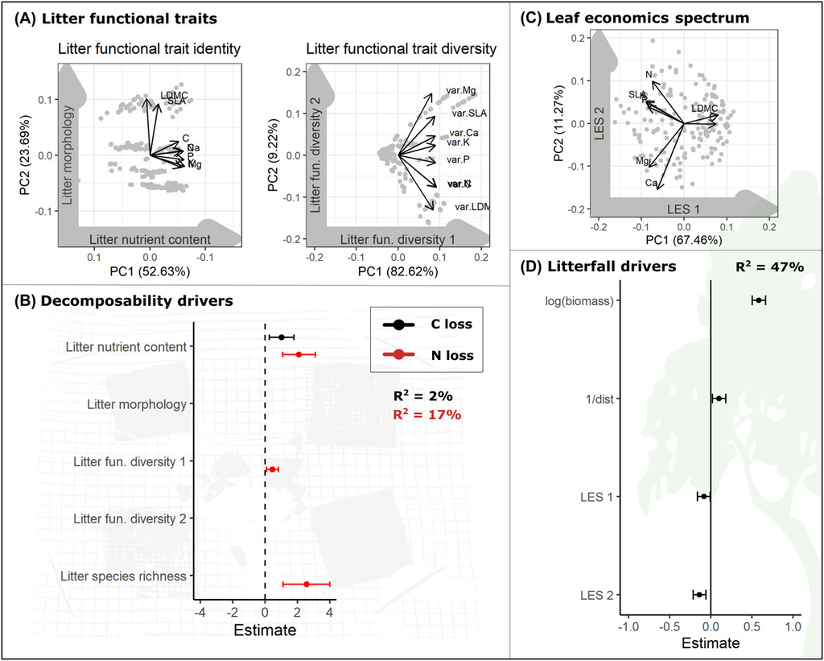

**Figure 4**

Leaf litter functional trait identity and diversity (A), decomposability drivers (B), leaf economics spectrum (LES) in Biodiversity Ecosystem Functioning (BEF) China (C), and drivers of the amount of species-specific litterfall (D). (A) Principal component analysis (PCA) of litter functional trait identity and diversity. Litter functional trait identity consisted of litter chemical composition (litterbag C, N, P, Mg, Ca, K content) and litter leaf morphological traits (litterbag community weighted mean specific leaf area (SLA) and leaf dry matter content LDMC)), and litter functional trait diversity consisted of litter leaf functional trait variance within the litterbags (C, N, P, Mg, Ca, K, SLA, and LDMC variances). (B) Effects of litter nutrient content (PCA litter functional identity first axis), morphology (PCA litter functional identity second axis), functional diversity (PCA litter functional diversity first two axes), and litter species richness on litter decomposability (in terms of C and N loss in black and red, respectively). The plot shows the estimates and standard errors of the multi-predictor model fit after a step AIC selection procedure. Confidence intervals (95%) were drawn around the standardized effect estimate with a full line for significant effects (p-value < 0.05). (C) PCA of leaf functional trait (i.e. C, N, P, Mg, Ca, K concentration and SLA and LDMC). (D) Effects of tree biomass (‘log(biomass)'), tree closeness to the litter-trap (‘1/dist'), and leaf functional traits (i.e. LES from panel C) on the amount of species-specific litterfall collected in the trap. The plot shows the estimates and standard errors of the multi-predictor linear model after a step AIC selection procedure. Confidence intervals (95%) were drawn around the standardized effect estimate with a full line for significant effects (p-value < 0.05).

## Discussion

We studied the effects of tree species richness on leaf litter decomposition considering the amount of litterfall and its composition, litter decomposability, and the role of the microbial community in the decomposition process. Our results confirmed our hypotheses: tree species richness promoted litter decomposition (H1) and was mainly carried out by microbial decomposers (H2). Microbial decomposition increased with litter decomposability (H3), with the latter being driven by litter species richness and litter functional trait identity and diversity (H4). In addition, we showed a positive effect of tree species richness on the amount of litterfall and litter species richness (H5), while the amount of species-specific litterfall increased with increasing proximity to the trees and with tree biomass, and was modulated by the leaf functional traits (H5). Notably, these findings highlight the complex interplay among tree litter diversity, leaf traits related to litter decomposability, and the spatial arrangement of trees in determining microbial decomposition processes in subtropical forest ecosystems.

### Relationship between litter decomposition and soil microorganisms

We found that litter decomposition is mostly performed by soil microbial communities in the studied Chinese subtropical forest (H2). This observation is in contrast with previous measurements of woody litter decomposition, made in the same experiment, showing the significant role of soil meso- and macrofauna (Pietsch et al. 2019). However, it could be explained by the low abundance of soil meso- and macrofauna we observed during the experiment (Supporting information) and in the respective region (Xu et al. 2006, Wang et al. 2007). Therefore, changes in litter decomposition were primarily explained by changes in microbial decomposition. Notably, soil fauna removal even increased the decomposition rate in some samples (Fig. 3B), suggesting top-down control of microbial decomposers by meso- and macrofauna communities (Patoine et al. 2020). For instance, the presence of bacterial and fungal feeders could reduce microbial biomass (Crowther et al. 2013, Tobias-Hünefeldt et al. 2021), and/or the disturbance of fungal hyphae in the early stage of decomposition could reduce fungal activity (Ristok et al. 2019).

### Tree diversity mass and diversity effects on decomposition

Our results showed a positive effect of the amount of litterfall on total decomposition but not microbial decomposition. Increasing the litter cover on the ground may favor other groups of decomposers such as meso- and macro-fauna decomposers by providing suitable environmental conditions (Korboulewsky et al. 2016, Joly et al. 2017, Gottschall et al. 2019). Therefore, more investigation is needed to better understand the interplay between soil microbial community, meso-/macro-fauna community, and litter decomposition (Joly et al. 2018, 2020). In particular, we need to understand how soil microbial and fauna detritivore communities interact (Ristok et al. 2019, Joly et al. 2020) as well as their environmental drivers (Cesarz et al. 2022, Phillips et al. 2021) to better understand their combined effects on soil carbon dynamics. We showed that both diversity effect pathways – 1) diversity effects on litter decomposition by increasing the tree productivity and the amount of litterfall (i.e. mass effects) and 2) diversity effects on litter decomposition through litter species richness and microbial decomposition (i.e. diversity effects) – had similar effect size, highlighting the concurrence of tree diversity mass 1) and diversity 2) effects on litter decomposition through litterfall (Sonkoly et al. 2019). Together, tree diversity effects on ecosystem functions are multicausal due to combined mass and diversity effects, both being equivalent driving forces of ecosystem function.

### Nutrient content and litter diversity drive litter decomposability

Litter decomposability measurements allowed us to isolate the litter effect on decomposition from decomposer and environmental effects (García-Palacios et al. 2013, Zhang et al. 2018, Lin et al. 2021). Consistent with our expectations, we observed a positive effect of litter decomposability on microbial decomposition. Moreover, we estimated that up to 20% of litter decomposition is driven by variations in litter decomposability. These results support previous observations showing that the litter composition and quality is a driving force in litter decomposition (Fanin et al. 2012, Joly et al. 2017, Zhang et al. 2018, Rosenfield et al. 2020).

Together, our results showed that litter nutrient content and litter diversity are driving decomposition, which was also observed in earlier studies (Fanin et al. 2012, Joly et al. 2017, Liu et al. 2021, Zhou et al. 2020). Two main mechanisms can explain these observations: 1) increasing leaf nutrient contents provided to the decomposer community reduces stoichiometric limitations (Fanin et al. 2012, Rosenfield et al. 2020) and 2) increasing substrate diversity leads to a higher niche partitioning of the decomposer community (Hooper et al. 2000, Ebeling et al. 2014). However, only a small fraction of the litter decomposability was explained by our models (i.e. 2% of C loss and 17% of N loss). Our analyses were conducted on fresh leaf trait measurements, yet leaf functional traits, especially leaf chemical composition, might change greatly during litterfall due to resorption mechanisms (Brant and Chen 2015). Therefore, litter functional traits rather than fresh leaf functional traits might be more relevant to measure litter quality effect on litter decomposition. In addition, other key aspects are still missing in our models, such as other chemical components like polyphenols and tannins contents (Ristok et al. 2019) or structural components such as celluloses, hemicelluloses, or lignin (Fioretto et al. 2005, Hättenschwiler et al. 2005, Austin and Ballaré 2010).

### Tree diversity and functional drivers of litterfall spatial distribution

Litterfall is the significant carbon flux from the canopy to the forest floor; therefore, an increase in the amount of litterfall and litter decomposition increase soil carbon storage (Xu et al. 2018). We demonstrated that tree species richness increased the amount of litterfall, confirming previous findings (Huang et al. 2017). Moreover, the amount of species-specific litterfall increased with increasing tree biomass and proximity to the trees and was modulated by leaf functional traits. These results provide some of the first empirical evidence of tree diversity effects on the spatial heterogeneity of litterfall composition at small spatial scales (i.e. a fraction of meters around the sampling point) and suggest a trait- and distance-based mediation of litterfall effects on decomposition in forests. Thus, our results emphasize the importance of considering small-scale processes and plot spatial heterogeneity to understand ecosystem functioning. Moreover, these small-scale processes and their drivers are potentially vital in understanding above- and belowground drivers of biodiversity, on top of plot-, field-, and landscape-level drivers (Le Provost et al. 2021).

Spatially heterogeneous distribution of litter composition and leaf trait effects on decomposition may cause spatial heterogeneity in litter decomposition and thus nutrient cycling. The distance-based mediation of litterfall will promote litter decomposition at two levels: on the one hand, a small part of litter originating from more distant trees could enhance decomposition by increasing litter diversity (Gessner et al. 2010, Trogisch et al. 2016, Joly et al. 2017, Zhang et al. 2018). On the other hand, most litter will accumulate close to the source tree, increasing litter decomposition due to increased litterfall and home-field advantages (Vogel et al. 2013, Fanin et al. 2021). The accumulation of species-specific litter close to each tree may favor species-specific decomposer communities (such as found in grassland soils, Bezemer et al. 2010). Therefore, spatial heterogeneity of litter at the plot level will sustain a high decomposer meta-community diversity (Hooper et al. 2000). A diverse meta-community is expected to promote ecosystem functioning (Grman et al. 2018, Mori et al. 2018, Häussler et al. 2020) and stability (Mougi and Kondoh 2016, Wang et al. 2021). However, these novel insights need further theoretical and empirical investigation to map and predict litter composition, decomposition, and decomposer meta-community dynamics at the plot level. Therefore, spatial experiments and modeling at small scales are essential to understand litter dispersal and the consequences for decomposition and mineralization processes that determine nutrient availability for plants.

## Conclusion

The present study provides new mechanistic insights into the impact of tree diversity on litter decomposition in subtropical forests and its consequences for carbon and nitrogen cycling. We showed that tree diversity enhances litter decomposition by increasing the amount of litterfall and litter species richness, highlighting the multiple effects of tree diversity on litter decomposition. Moreover, we suggest that litter mass and diversity effects of tree diversity are two significant aspects to consider for understanding tree diversity effects on ecosystem functioning; and thus, both aspects of tree diversity should be better explored in the future. We also showed the key role of the spatial distribution of litterfall for litter decomposition. Further research should consider the spatial distribution of trees to understand the spatial heterogeneity of tree products such as litterfall and root exudates, and thus the consequences for ecosystem functions like carbon and nitrogen cycling in forests.

### Acknowledgements

– We thank the TreeDì and Experimental Interaction Ecology research groups for their support, especially Alfred Lochner and Anja Zeuner, for their help with the lab measurements and the many local helpers for their help with the field sampling.

### Funding

– This work was supported by the Deutsche Forschungsgemeinschaft (DFG, German Research Foundation – 319936945/GRK2324 and Ei 862/18-1), the University of Chinese Academy of Sciences (UCAS), and CAS Strategic Priority Research Programme (XDA20050104). We gratefully acknowledge the support by the German Centre for Integrative Biodiversity Research (iDiv) funded by the German Research Foundation (DFG– FZT 118, 202548816).

### Author contributions

**Rémy Beugnon**: Conceptualization (lead); Data curation (lead); Formal analysis (lead); Investigation (lead); Methodology (lead); Validation (lead); Visualization (lead); Writing – original draft (lead); Writing – review and editing (lead). **Nico Eisenhauer**: Conceptualization (lead); Funding acquisition (lead); Investigation (supporting); Methodology (supporting); Supervision (supporting); Writing – original draft (equal); Writing – review and editing (supporting). **Helge Bruelheide**: Conceptualization (equal); Funding acquisition (lead); Writing – review and editing (equal). **Andréa Davrinche**: Formal analysis (equal); Investigation (equal); Writing – review and editing (equal). **Jianqing Du**: Conceptualization (equal); Writing – review and editing (equal). **S****ylvia Haider**: Funding acquisition (equal); Investigation (supporting); Writing – review and editing (equal). **Georg Hähn**: Data curation (equal); Formal analysis (equal); Investigation (equal); Writing – review and editing (equal). **Mariem Saadani**: Investigation (equal); Writing – review and editing (equal). **Bala Singavarapu**: Investigation (equal); Writing – review and editing (equal). **Marie Sünnemann**: Conceptualization (supporting); Investigation (supporting); Writing – review and editing (equal). **Lise Thouvenot**: Conceptualization (supporting); Investigation (supporting); Writing – review and editing (equal). **Yanfen Wang**: Conceptualization (supporting); Funding acquisition (supporting); Writing – review and editing (equal). **Tesfaye Wubet**: Conceptualization (supporting); Funding acquisition (supporting); Writing – review and editing (equal). **Kai Xue**: Conceptualization (supporting); Funding acquisition (supporting); Writing – review and editing (equal). **Simone Cesarz**: Conceptualization (equal); Funding acquisition (equal); Supervision (lead); Writing – original draft (supporting); Writing – review and editing (equal).

## References

[figure not shown]

[Early View](https://onlinelibrary.wiley.com/toc/16000706/0/0)

Online Version of Record before inclusion in an issue

e09751

### Recommended


back